# CENG 3516 Statistical Computing Final Report

Cansel Hatice Küçükyılmaz - 170709049

Muğla Sıtkı Koçman University Faculty of Engineering, Computer Engineering

15 June 2021

# Istanbul Metropolitan Municipality Student Aid

# Data collection

## Description of Data

This dataset contains information about the students who received educational assistance over the years. In this data source, it includes the number of students given educational aid by the Istanbul Metropolitan Municipality.

## Dataset Information

| Column | Description |
| --- | --- |
| ASSISTANCE_YEAR | It is the field that includes the year of education aid. |
| ASSISTANCE_TERM | It is the field that includes the period of education aid. |
| UNIVERSITY | Information on the school where students who receive educational aid study. |
| AGE | Ages of students receiving educational aid. |
| COUNTY | District knowledge of the students receiving educational aid. |
| NUMBER_OF_STUDENTS | Number of students receiving educational aid |

**Data Source:** https://data.ibb.gov.tr/dataset/8badf78e-2307-46cb-b3a1-83fc4e5d804a/resource/69484e6b-3440-4a61-bf59-19e5fafd49a9/download/dam_occupancy.csv  
**License: Istanbul Metropolitan Municipality Open Data License**

```r
library(ggplot2)
library(dplyr)
library(tidyverse)
library(sp)
library(ggplot2)
library(ggplot2)
library(DescTools)
```

# Analyses

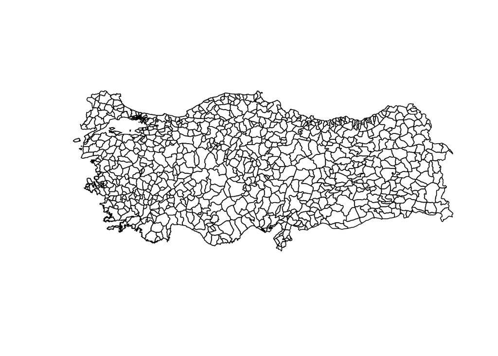

```r
tr1<- readRDS("gadm36_TUR_2_sp.rds")
plot(tr1)
```

First of all, I would like to show the density of the students to whom IBB grants scholarships, by district, on the Istanbul district map. For this, I first downloaded turkey spatial data from GAMD. https://gadm.org/download_country_v3.html.

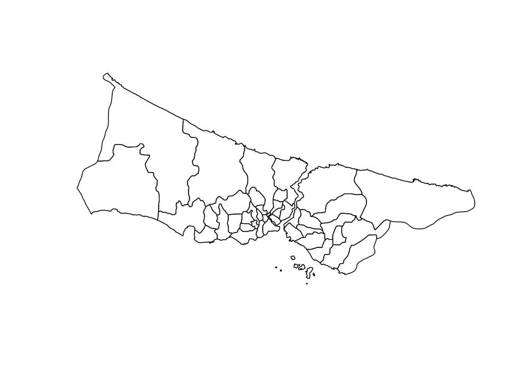

```r
istanbul=tr1%>%subset(NAME_1=="Istanbul")
plot(istanbul)
```

In this turkey data, I pulled the istanbul data from the NAME_1 colum. And I had the map of Istanbul drawn by districts.

```r
istanbul@data$NAME_2 <- gsub("Arnavutkoy","Arnavutköy",istanbul@data$NAME_2 )
istanbul@data$NAME_2 <- gsub("Basaksehir","Başaksehir",istanbul@data$NAME_2 )
istanbul@data$NAME_2 <- gsub("Atasehir","Ataşehir",istanbul@data$NAME_2 )
istanbul@data$NAME_2 <- gsub("Basaksehir","Başakşehir",istanbul@data$NAME_2 )
istanbul@data$NAME_2 <- gsub("Çekmekoy","Çekmeköy",istanbul@data$NAME_2 )
istanbul@data$NAME_2 <- gsub("Beylikduzu","Beylikdüzü",istanbul@data$NAME_2 )

istanbul@data %>% as_tibble() %>% head(10)
```

| GID_0 | NAME_0 | GID_1 | NAME_1 | NL_NAME_1 | GID_2 | NAME_2 | VARNAME_2 | NL_NAME_2 | TYPE_2 | ENGTYPE_2 | CC_2 | HASC_2 |
| --- | --- | --- | --- | --- | --- | --- | --- | --- | --- | --- | --- | --- |
| TUR | Turkey | TUR.40_1 | Istanbul | NA | TUR.40.1_1 | Adalar | NA | NA | District | District | NA | TR.IB.AD |
| TUR | Turkey | TUR.40_1 | Istanbul | NA | TUR.40.2_1 | Arnavutköy | NA | NA | District | District | NA | NA |
| TUR | Turkey | TUR.40_1 | Istanbul | NA | TUR.40.3_1 | Ataşehir | NA | NA | District | District | NA | NA |
| TUR | Turkey | TUR.40_1 | Istanbul | NA | TUR.40.4_1 | Avcılar | NA | NA | District | District | NA | TR.IB.AV |
| TUR | Turkey | TUR.40_1 | Istanbul | NA | TUR.40.5_1 | Bağcılar | NA | NA | District | District | NA | TR.IB.BA |
| TUR | Turkey | TUR.40_1 | Istanbul | NA | TUR.40.6_1 | Bahçelievler | NA | NA | District | District | NA | TR.IB.BC |
| TUR | Turkey | TUR.40_1 | Istanbul | NA | TUR.40.7_1 | Bakırköy | NA | NA | District | District | NA | TR.IB.BK |
| TUR | Turkey | TUR.40_1 | Istanbul | NA | TUR.40.8_1 | Başaksehir | NA | NA | District | District | NA | NA |
| TUR | Turkey | TUR.40_1 | Istanbul | NA | TUR.40.9_1 | Bayrampaşa | NA | NA | District | District | NA | TR.IB.BP |
| TUR | Turkey | TUR.40_1 | Istanbul | NA | TUR.40.10_1 | Beşiktaş | NA | NA | District | District | NA | TR.IB.BE |

I saw that the district names were wrong in some of the data from the data set and I corrected them with the help of the gsub function.

```r
istanbul@data$NAME_2
```

```
##  [1] "Adalar"        "Arnavutköy"    "Ataşehir"      "Avcılar"
##  [5] "Bağcılar"      "Bahçelievler"  "Bakırköy"      "Başaksehir"
##  [9] "Bayrampaşa"    "Beşiktaş"      "Beykoz"        "Beylikdüzü"
## [13] "Beyoğlu"       "Büyükçekmece"  "Çatalca"       "Çekmeköy"
## [17] "Esenler"       "Esenyurt"      "Eyüp"          "Fatih"
## [21] "Gaziosmanpaşa" "Güngören"      "Kadıköy"       "Kağıthane"
## [25] "Kartal"        "Küçükçekmece"  "Maltepe"       "Pendik"
## [29] "Sancaktepe"    "Sarıyer"       "Şile"          "Şişli"
## [33] "Sultanbeyli"   "Sultangazi"    "Tuzla"         "Ümraniye"
## [37] "Üsküdar"       "Zeytinburnu"
```

```r
istdata<-fortify(istanbul)
head(istdata)
```

|  | long | lat | order | hole | piece | id | group |
| --- | --- | --- | --- | --- | --- | --- | --- |
| 1 | 29.12958 | 40.87569 | 1 | FALSE | 1 | 114478 | 114478.1 |
| 2 | 29.12958 | 40.87542 | 2 | FALSE | 1 | 114478 | 114478.1 |
| 3 | 29.13042 | 40.87542 | 3 | FALSE | 1 | 114478 | 114478.1 |
| 4 | 29.13042 | 40.87514 | 4 | FALSE | 1 | 114478 | 114478.1 |
| 5 | 29.13347 | 40.87514 | 5 | FALSE | 1 | 114478 | 114478.1 |
| 6 | 29.13347 | 40.87486 | 6 | FALSE | 1 | 114478 | 114478.1 |

We need to convert the spatial data we have into a data.frame object, for this I made a dataframe with the fortify function.

```r
ibb_yardim <- read.csv("ibb-genc-universiteli.csv")
head(ibb_yardim)
```

|  | X_id | ASSISTANCE_YEAR | ASSISTANCE_TERM | UNIVERSITY | AGE | COUNTY | NUMBER_OF_STUDENTS |
| --- | --- | --- | --- | --- | --- | --- | --- |
| 1 | 1 | 2019 | 1 | Karadeniz Teknik Üniversitesi | 25 | BAĞCILAR | 1 |
| 2 | 2 | 2020 | 1 | Boğaziçi Üniversitesi | 22 | BEYLİKDÜZÜ | 1 |
| 3 | 3 | 2020 | 1 | Manisa Celâl Bayar Üniversitesi | 20 | SULTANBEYLİ | 3 |
| 4 | 4 | 2020 | 1 | İstanbul Bilgi Üniversitesi | 19 | AVCILAR | 1 |
| 5 | 5 | 2019 | 2 | İstanbul Medeniyet Üniversitesi | 21 | ÜSKÜDAR | 6 |
| 6 | 6 | 2019 | 2 | Muğla Sıtkı Koçman Üniversitesi | 23 | KÜÇÜKÇEKMECE | 1 |

I uploaded the Student Aid data that we pulled from IBB https://data.ibb.gov.tr/dataset/8badf78e-2307-46cb-b3a1-83fc4e5d804a/resource/69484e6b-3440-4a61-bf59-19e5fafd49a9/download/dam_occupancy.csv to the workspace with the help of the read.csv function.

```r
ibb_yardim$COUNTY <- str_to_title(ibb_yardim$COUNTY)
head(ibb_yardim)
```

|  | X_id | ASSISTANCE_YEAR | ASSISTANCE_TERM | UNIVERSITY | AGE | COUNTY | NUMBER_OF_STUDENTS |
| --- | --- | --- | --- | --- | --- | --- | --- |
| 1 | 1 | 2019 | 1 | Karadeniz Teknik Üniversitesi | 25 | Bağcilar | 1 |
| 2 | 2 | 2020 | 1 | Boğaziçi Üniversitesi | 22 | Beyli̇kdüzü | 1 |
| 3 | 3 | 2020 | 1 | Manisa Celâl Bayar Üniversitesi | 20 | Sultanbeyli̇ | 3 |
| 4 | 4 | 2020 | 1 | İstanbul Bilgi Üniversitesi | 19 | Avcilar | 1 |
| 5 | 5 | 2019 | 2 | İstanbul Medeniyet Üniversitesi | 21 | Üsküdar | 6 |
| 6 | 6 | 2019 | 2 | Muğla Sıtkı Koçman Üniversitesi | 23 | Küçükçekmece | 1 |

District names were entered in capital letters, I converted them to title format with the help of the str_to_title function.

```r
table(ibb_yardim$COUNTY)
```

```
##
##        Adalar    Arnavutköy      Ataşehi̇r       Avcilar      Bağcilar
##            24           881           641           847          1398
##  Bahçeli̇evler      Bakirköy    Başakşehi̇r    Bayrampaşa      Beşi̇ktaş
##          1172           224           854           571           177
##        Beykoz    Beyli̇kdüzü       Beyoğlu  Büyükçekmece       Çatalca
##           435           649           493           523           199
##      Çekmeköy       Esenler      Esenyurt          Eyüp    Eyüpsultan
##           570          1040          1362             4           694
##         Fati̇h Gazi̇osmanpaşa      Güngören       Kadiköy     Kağithane
##           702           916           706           379           841
##        Kartal  Küçükçekmece       Maltepe        Pendi̇k    Sancaktepe
##           904          1150           774          1207          1051
##       Sariyer          Şi̇le       Si̇li̇vri̇         Şi̇şli̇   Sultanbeyli̇
##           435            82           337           392          1027
##    Sultangazi̇         Tuzla      Ümrani̇ye       Üsküdar   Zeyti̇nburnu
##          1182           629           982           728           693
```

Here, It seems that some county names are wrong.

```r
ibb_yardim$COUNTY<-gsub("Bağcilar" ,"Bağcılar",ibb_yardim$COUNT)
ibb_yardim$COUNTY<-gsub("Bakirköy" ,"Bakırköy",ibb_yardim$COUNT)
ibb_yardim$COUNTY<-gsub("Avcilar" ,"Avcılar",ibb_yardim$COUNT)
ibb_yardim$COUNTY<-gsub("Pendi̇k" ,"Pendik",ibb_yardim$COUNTY)
ibb_yardim$COUNTY<-gsub("Sariyer" ,"Sarıyer",ibb_yardim$COUNTY)
ibb_yardim$COUNTY<-gsub("Gazi̇osmanpaşa" ,"Gaziosmanpaşa",ibb_yardim$COUNTY)
ibb_yardim$COUNTY<-gsub("Beyli̇kdüzü" ,"Beylikdüzü",ibb_yardim$COUNTY)
ibb_yardim$COUNTY<-gsub("Bahçeli̇evler" ,"Bahçelievler",ibb_yardim$COUNTY)
ibb_yardim$COUNTY<-gsub("Ümrani̇ye" ,"Ümraniye",ibb_yardim$COUNTY)
ibb_yardim$COUNTY<-gsub("Fati̇h" ,"Fatih",ibb_yardim$COUNTY)
ibb_yardim$COUNTY<-gsub("Zeyti̇nburnu" ,"Zeytinburnu",ibb_yardim$COUNTY)
ibb_yardim$COUNTY<-gsub("Kağithane" ,"Kağıthane",ibb_yardim$COUNTY)
ibb_yardim$COUNTY<-gsub("Sultanbeyli̇" ,"Sultanbeyli",ibb_yardim$COUNTY)
ibb_yardim$COUNTY<-gsub("Cekmekoy" ,"Çekmeköy",ibb_yardim$COUNTY)
ibb_yardim$COUNTY<-gsub("Sultangazi̇", "Sultangazi",ibb_yardim$COUNTY)
ibb_yardim$COUNTY<-gsub("Şi̇şli̇", "Şişli",ibb_yardim$COUNTY)
ibb_yardim$COUNTY<-gsub("Si̇li̇vri̇","Şişli",ibb_yardim$COUNTY)
ibb_yardim$COUNTY<-gsub("Başakşehi̇r","Başakşehir",ibb_yardim$COUNTY)
ibb_yardim$COUNTY<-gsub("Ataşehi̇r","Ataşehir",ibb_yardim$COUNTY)
ibb_yardim$COUNTY<-gsub("Şi̇le","Şile",ibb_yardim$COUNTY)
ibb_yardim$COUNTY<-gsub("Kadiköy","Kadıköy",ibb_yardim$COUNTY)
ibb_yardim$COUNTY<-gsub("Beşi̇ktaş","Beşiktaş",ibb_yardim$COUNTY)
```

I corrected the wrong county names with the help of the gsub function.

```r
year2019 <- ibb_yardim%>%filter(ASSISTANCE_YEAR==2019)
```

I generated a sub-dataframe for the students who applied in 2019.

```r
totalStudents_2019 <-  aggregate(NUMBER_OF_STUDENTS~COUNTY,year2019,sum)




head(totalStudents_2019%>%as_tibble)
```

| COUNTY | NUMBER_OF_STUDENTS |
| --- | --- |
| Adalar | 17 |
| Arnavutköy | 838 |
| Ataşehir | 579 |
| Avcılar | 861 |
| Bağcılar | 1931 |
| Bahçelievler | 1462 |

The total number of scholarships earned by students by district.

```r
istanbul@data$NAME_2
```

```
##  [1] "Adalar"        "Arnavutköy"    "Ataşehir"      "Avcılar"
##  [5] "Bağcılar"      "Bahçelievler"  "Bakırköy"      "Başaksehir"
##  [9] "Bayrampaşa"    "Beşiktaş"      "Beykoz"        "Beylikdüzü"
## [13] "Beyoğlu"       "Büyükçekmece"  "Çatalca"       "Çekmeköy"
## [17] "Esenler"       "Esenyurt"      "Eyüp"          "Fatih"
## [21] "Gaziosmanpaşa" "Güngören"      "Kadıköy"       "Kağıthane"
## [25] "Kartal"        "Küçükçekmece"  "Maltepe"       "Pendik"
## [29] "Sancaktepe"    "Sarıyer"       "Şile"          "Şişli"
## [33] "Sultanbeyli"   "Sultangazi"    "Tuzla"         "Ümraniye"
## [37] "Üsküdar"       "Zeytinburnu"
```

County names from spatial data.

```r
students.number.based.on.county<- data_frame(id=rownames(istanbul@data), COUNTY=istanbul@data$NAME_2) %>% full_join(totalStudents_2019, by = "COUNTY")
```

Using full join, I combined the data we pulled from Spatial data and the data of students who received scholarships in 2019 from IBB based on county.

```r
head(students.number.based.on.county)
```

| id | COUNTY | NUMBER_OF_STUDENTS |
| --- | --- | --- |
| 114477 | Adalar | 17 |
| 112022 | Arnavutköy | 838 |
| 113929 | Ataşehir | 579 |
| 113522 | Avcılar | 861 |
| 113649 | Bağcılar | 1931 |
| 113897 | Bahçelievler | 1462 |

```r
final_map <- left_join(istdata, students.number.based.on.county, by = "id")
head(final_map)
```

|  | long | lat | order | hole | piece | id | group | COUNTY | NUMBER_OF_STUDENTS |
| --- | --- | --- | --- | --- | --- | --- | --- | --- | --- |
| 1 | 29.12958 | 40.87569 | 1 | FALSE | 1 | 114478 | 114478.1 | NA | NA |
| 2 | 29.12958 | 40.87542 | 2 | FALSE | 1 | 114478 | 114478.1 | NA | NA |
| 3 | 29.13042 | 40.87542 | 3 | FALSE | 1 | 114478 | 114478.1 | NA | NA |
| 4 | 29.13042 | 40.87514 | 4 | FALSE | 1 | 114478 | 114478.1 | NA | NA |
| 5 | 29.13347 | 40.87514 | 5 | FALSE | 1 | 114478 | 114478.1 | NA | NA |
| 6 | 29.13347 | 40.87486 | 6 | FALSE | 1 | 114478 | 114478.1 | NA | NA |

join both data using left_join function.

```r
table(students.number.based.on.county$id)
```

```
##
## 111142 112022 112448 112472 112689 112817 112914 113225 113261 113283 113356
##      1      1      1      1      1      1      1      1      1      1      1
## 113415 113440 113450 113474 113522 113541 113548 113610 113629 113649 113705
##      1      1      1      1      1      1      1      1      1      1      1
## 113721 113730 113759 113808 113843 113845 113891 113897 113929 113938 113952
##      1      1      1      1      1      1      1      1      1      1      1
## 113986 114047 114093 114165 114477
##      1      1      1      1      1
```

```r
students.number.based.on.county
```

| id | COUNTY | NUMBER_OF_STUDENTS |
| --- | --- | --- |
| 114477 | Adalar | 17 |
| 112022 | Arnavutköy | 838 |
| 113929 | Ataşehir | 579 |
| 113522 | Avcılar | 861 |
| 113649 | Bağcılar | 1931 |
| 113897 | Bahçelievler | 1462 |
| 113986 | Bakırköy | 169 |
| 113283 | Başaksehir | NA |
| 113610 | Bayrampaşa | 472 |
| 113450 | Beşiktaş | 115 |

[output cut: 30 more lines]

```r
str(students.number.based.on.county)
```

```
## tibble [40 × 3] (S3: tbl_df/tbl/data.frame)
##  $ id                : chr [1:40] "114477" "112022" "113929" "113522" ...
##  $ COUNTY            : chr [1:40] "Adalar" "Arnavutköy" "Ataşehir" "Avcılar" ...
##  $ NUMBER_OF_STUDENTS: int [1:40] 17 838 579 861 1931 1462 169 NA 472 115 ...
```

```r
students.number.based.on.county$id=as.character(as.numeric(students.number.based.on.county$id)+1)
```

There is a difference on ids so I added 1 to remove the difference.

```r
head(students.number.based.on.county)
```

| id | COUNTY | NUMBER_OF_STUDENTS |
| --- | --- | --- |
| 114478 | Adalar | 17 |
| 112023 | Arnavutköy | 838 |
| 113930 | Ataşehir | 579 |
| 113523 | Avcılar | 861 |
| 113650 | Bağcılar | 1931 |
| 113898 | Bahçelievler | 1462 |

```r
final_map <- left_join(istdata, students.number.based.on.county, by = "id")
head(final_map)
```

|  | long | lat | order | hole | piece | id | group | COUNTY | NUMBER_OF_STUDENTS |
| --- | --- | --- | --- | --- | --- | --- | --- | --- | --- |
| 1 | 29.12958 | 40.87569 | 1 | FALSE | 1 | 114478 | 114478.1 | Adalar | 17 |
| 2 | 29.12958 | 40.87542 | 2 | FALSE | 1 | 114478 | 114478.1 | Adalar | 17 |
| 3 | 29.13042 | 40.87542 | 3 | FALSE | 1 | 114478 | 114478.1 | Adalar | 17 |
| 4 | 29.13042 | 40.87514 | 4 | FALSE | 1 | 114478 | 114478.1 | Adalar | 17 |
| 5 | 29.13347 | 40.87514 | 5 | FALSE | 1 | 114478 | 114478.1 | Adalar | 17 |
| 6 | 29.13347 | 40.87486 | 6 | FALSE | 1 | 114478 | 114478.1 | Adalar | 17 |

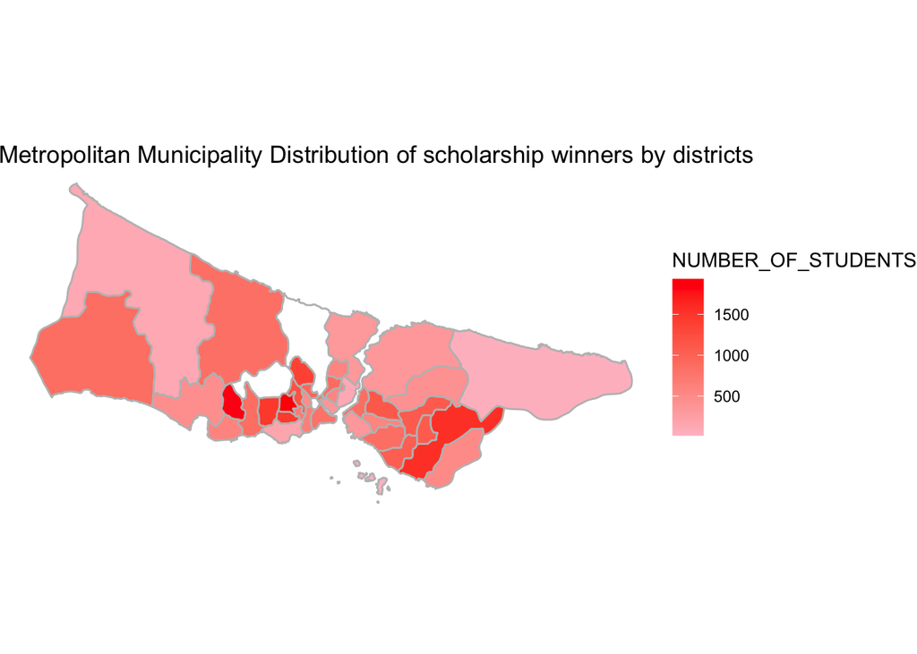

```r
ggplot(final_map) +geom_polygon( aes(x = long, y = lat, group = group, fill = NUMBER_OF_STUDENTS), color = "grey") +
coord_map() +theme_void() + labs(title = "Istanbul Metropolitan Municipality Distribution of scholarship winners by districts") +
scale_fill_gradient(low = "pink", high = "red",na.value = "white") +
theme(plot.title = element_text(hjust = 0.5),plot.subtitle = element_text(hjust = 0.5))
```

The plot above shows the distribution of scholarship winners by districts. The provinces are Esenyurt, Pendik and Bağcılar has the highest number of scholarships.

```r
mean(ibb_yardim$ASSISTANCE_TERM)
```

```
## [1] 1.282475
```

The average scholarship period for scholarship winners is 1.28 term.

```r
mean(ibb_yardim$AGE)
```

```
## [1] 21.35322
```

The average age of scholarship winners is 21.35 years.

```r
median(ibb_yardim$AGE)
```

```
## [1] 21
```

The median of scholarship winners’ age is 21 years.

```r
Mode(ibb_yardim$AGE) #with capital M
```

```
## [1] 21
## attr(,"freq")
## [1] 5611
```

21 is the most recurring age among scholarship recipient students.

# Measure of Dispersion

**Range**

```r
 range<-range(ibb_yardim$AGE)
range[2]-range[1] #Shows the difference between minimum and maximum values
```

```
## [1] 10
```

The difference between minimum age and maximum age is 10.

**Calculating Quantiles**

```r
quantile(ibb_yardim$AGE,0.75) #3rd quantile
```

```
## 75%
##  23
```

The 75% of the students’ age is 23 or below.

**Interquartile Range**

```r
IQR(ibb_yardim$AGE)
```

```
## [1] 3
```

It refers to spread of 50% of the data.

**Variance and Standard Deviation**

The variance is a measure of how far each value in the data set is from the mean.Standard deviation is the measure of spread most commonly used in statistical practice when the mean is used to calculate central tendency. Thus, it measures spread around the mean.

```r
sd(ibb_yardim$AGE)
```

```
## [1] 1.820437
```

Standard Deviation is 1.82, far each age in the data set is from the average age.

**Covariance**

```r
cov(ibb_yardim$AGE,ibb_yardim$ASSISTANCE_TERM)
```

```
## [1] 0.09484637
```

There are positive relationship between age and assistance time.

```r
chisq.test(ibb_yardim$COUNTY,ibb_yardim$UNIVERSITY)
```

```
##
##  Pearson's Chi-squared test
##
## data:  ibb_yardim$COUNTY and ibb_yardim$UNIVERSITY
## X-squared = 11495, df = 7866, p-value < 2.2e-16
```

Since p value is less than 0.05, It can be said that county and university are dependent variables.

**Measure of Skewness**

```r
library(moments)
skewness(ibb_yardim$AGE)
```

```
## [1] 0.3226981
```

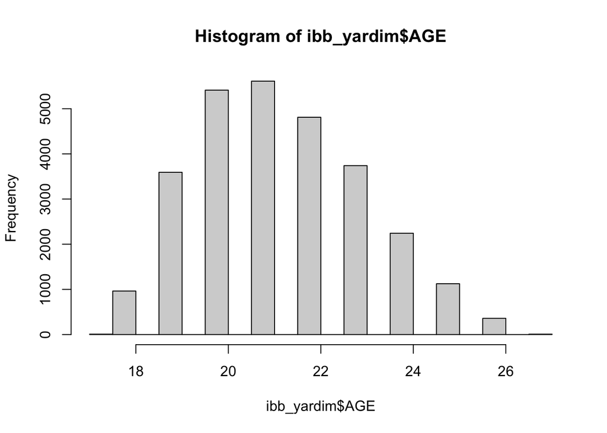

```r
hist(ibb_yardim$AGE)
```

It looks like data has bell shape.

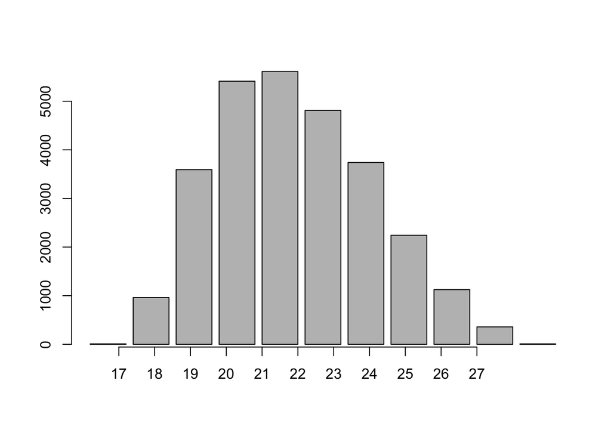

```r
library(dplyr)
ages <- data.frame(ibb_yardim$AGE ) %>% group_by(ibb_yardim$AGE) %>% count(ibb_yardim$AGE)

barplot(ages$n)
ageInt <- c(17,18,19,20,21,22,23,24,25,26,27)
axis(side = 1, at = 1:11, labels = ageInt)
```

In the figure above, the distribution of scholarship recipients by age is given. According to age distribution, the number of students at the age of 21 receiving scholarships is high.

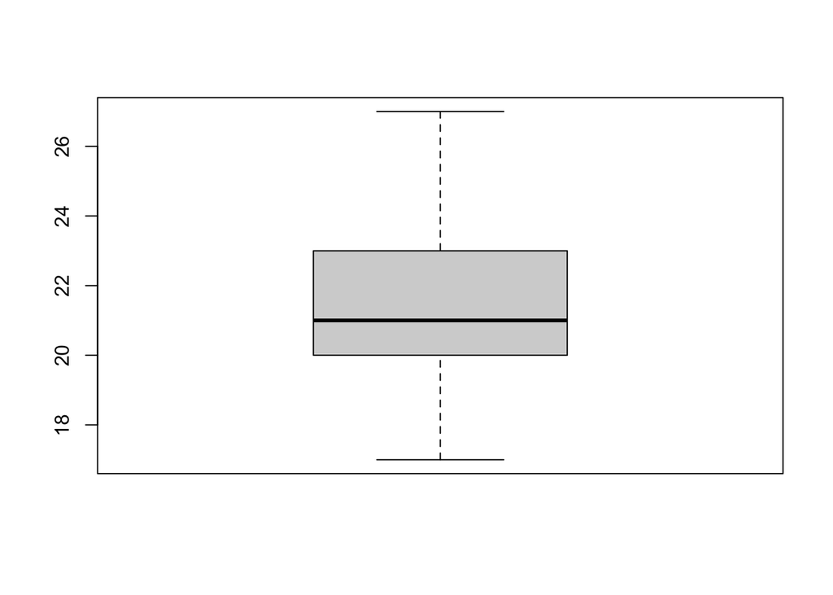

```r
boxplot(ibb_yardim$AGE)
```

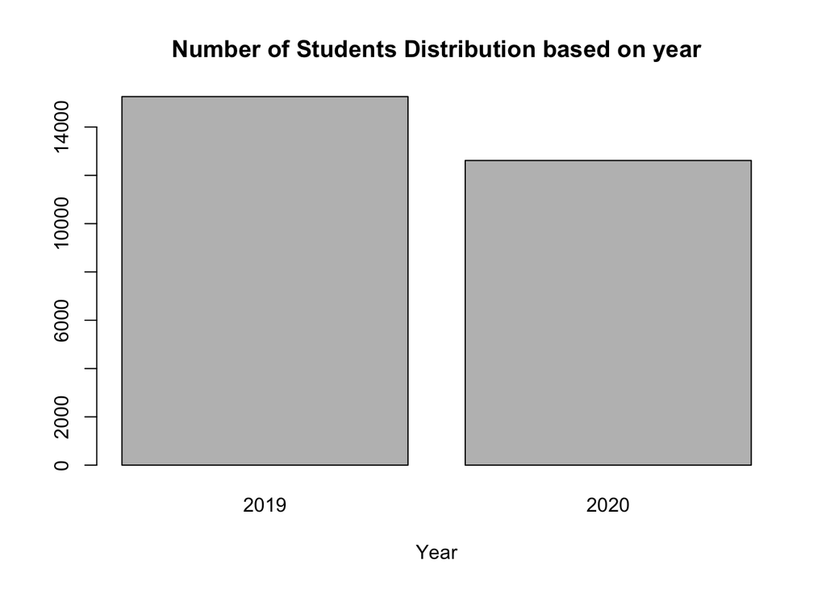

```r
counts <- table(ibb_yardim$ASSISTANCE_YEAR)
barplot(counts, main="Number of Students Distribution based on year",
   xlab="Year")
```

According to the figure above, it can be said that more students received scholarships in 2019.

```r
year2019 <- ibb_yardim%>%filter(ASSISTANCE_YEAR==2019)
```

```r
mean(year2019$AGE)
```

```
## [1] 21.63571
```

The average age of the students who received a scholarship in 2019 is 21.63.

```r
totalStudents_2019 <-  aggregate(NUMBER_OF_STUDENTS~UNIVERSITY,year2019,sum)

head(totalStudents_2019%>%as_tibble)
```

| UNIVERSITY | NUMBER_OF_STUDENTS |
| --- | --- |
| Abdullah Gül Üniversitesi | 8 |
| Acıbadem Mehmet Ali Aydınlar Üniversitesi | 20 |
| Adana Alparslan Türkeş Bilim Ve Teknoloji Üniversitesi | 8 |
| Adıyaman Üniversitesi | 24 |
| Afyon Kocatepe Üniversitesi | 99 |
| Afyonkarahisar Sağlık Bilimleri Üniversitesi | 12 |

Distribution of scholarship recipients in 2019 by university.

[figure not shown]

```r
ggplot(totalStudents_2019, aes(x=UNIVERSITY, y=NUMBER_OF_STUDENTS, fill=UNIVERSITY))+
  geom_bar(stat = "identity") +
  labs(title = "Students class BarChart", x="Class", y="Response")
```

# Confidence Intervals

### Finding confidence interval for number of students evaluating based on year:

```r
year.2019<- subset(ibb_yardim, ASSISTANCE_YEAR== 2019)
year.2020 <- subset(ibb_yardim, ASSISTANCE_YEAR == 2020)
```

```r
Conf.2019 <-t.test(year.2019$NUMBER_OF_STUDENTS)$conf.int
Conf.2019
```

```
## [1] 1.896475 1.959619
## attr(,"conf.level")
## [1] 0.95
```

```r
Conf.2020 <- t.test(year.2020$NUMBER_OF_STUDENTS)$conf.int
Conf.2020
```

```
## [1] 2.599565 2.734402
## attr(,"conf.level")
## [1] 0.95
```

### Finding confidence interval for age evaluating based on university:

```r
gtu <- subset(year2019, UNIVERSITY=="Gebze Teknik Üniversitesi")
msku <- subset(year2019, UNIVERSITY =="Muğla Sıtkı Koçman Üniversitesi")
```

```r
# Calculating confidence interval for age of gtü students
gtuConf <- t.test(gtu$AGE)$conf.int
gtuConf
```

```
## [1] 21.30346 21.88172
## attr(,"conf.level")
## [1] 0.95
```

```r
 # Calculating confidence interval for age of mskü students
mskuConf <- t.test(msku$AGE)$conf.int
mskuConf
```

```
## [1] 21.29458 21.81399
## attr(,"conf.level")
## [1] 0.95
```

```r
ibb_yardim.UNIVERSITY <- data.frame(UNIVERSITY="Gebze Teknik Üniversitesi",
                                scoreType="AGE",
                                mean=mean(gtu$AGE),
                                lower=gtuConf[1],
                                upper=gtuConf[2])
```

```r
ibb_yardim.UNIVERSITY <- rbind(ibb_yardim.UNIVERSITY, data.frame(UNIVERSITY="Muğla Sıtkı Koçman Üniversitesi",
                                scoreType="AGE",
                                mean=mean(msku$AGE),
                                lower=mskuConf[1],
                                upper=mskuConf[2]))
```

```r
ibb_yardim.UNIVERSITY
```

| UNIVERSITY | scoreType | mean | lower | upper |
| --- | --- | --- | --- | --- |
| Gebze Teknik Üniversitesi | AGE | 21.59259 | 21.30346 | 21.88172 |
| Muğla Sıtkı Koçman Üniversitesi | AGE | 21.55429 | 21.29458 | 21.81399 |

Summary for Muğla Sıtkı Koçman Üniversitesi and Gebze Teknik Üniversitesi.

# Hypothesis Testing

### Test that the true average of MSKU students age is equal to 18.

H0: mu = 18 Ha: mu != 18

Assesing the normality.

```r
shapiro.test(msku$AGE)
```

```
##
##  Shapiro-Wilk normality test
##
## data:  msku$AGE
## W = 0.9503, p-value = 8.035e-06
```

```r
t.test(msku$AGE,
       alternative = "two.sided",
       mu=18,
       conf.level = 0.95)
```

```
##
##  One Sample t-test
##
## data:  msku$AGE
## t = 27.011, df = 174, p-value < 2.2e-16
## alternative hypothesis: true mean is not equal to 18
## 95 percent confidence interval:
##  21.29458 21.81399
## sample estimates:
## mean of x
##  21.55429
```

To conclude, as p-value < 0.05, the null hypothesis is rejected and the confidence interval is between 21.29 and 21.81 with 95% confident. It means the average of the students age is not equal to 18.

### Are there significant difference between mean of MSKU and GTU students’ age?

Check the variance:

```r
x <- subset(ibb_yardim, UNIVERSITY=="Muğla Sıtkı Koçman Üniversitesi")$AGE
y <- subset(ibb_yardim, UNIVERSITY=="Gebze Teknik Üniversitesi")$AGE

var.test(x, y)
```

```
##
##  F test to compare two variances
##
## data:  x and y
## F = 0.98652, num df = 305, denom df = 270, p-value = 0.9067
## alternative hypothesis: true ratio of variances is not equal to 1
## 95 percent confidence interval:
##  0.7815445 1.2431780
## sample estimates:
## ratio of variances
##          0.9865161
```

As p-value > 0.05, the null hypothesis is not rejected and the variances are equal. `

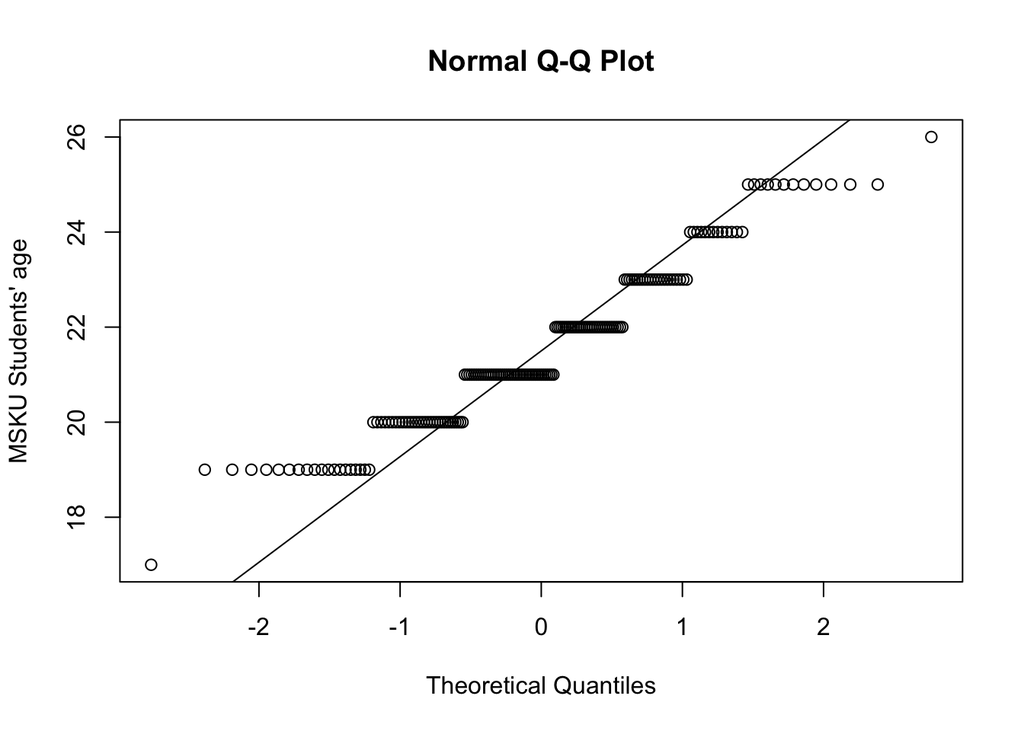

```r
qqnorm(msku$AGE, ylab = "MSKU Students' age")
qqline(msku$AGE)
```

```r
t.test(x=x, y=y, alternative = "two.sided", var.equal = TRUE,
       conf.level = 0.95)
```

```
##
##  Two Sample t-test
##
## data:  x and y
## t = 0.715, df = 575, p-value = 0.4749
## alternative hypothesis: true difference in means is not equal to 0
## 95 percent confidence interval:
##  -0.1868853  0.4008351
## sample estimates:
## mean of x mean of y
##  21.34314  21.23616
```